# FinalProject

Abdullah Ahmad, Shantanu Samant, Jesus Herrera (GroupE2)

12/9/2021

Myanmar Military Coup of 2021

**Abstract**

This report looks at records of individuals who were detained, imprisoned, or killed during the Myanmar Coup of 2021. We conduct a statistical analysis on the datasets to understand detainment better across age, sex and township. We also merge data related to the socioeconomic factors in different township in Myanmar. We then see what factors are responsible to contributing to the detainment in Myanmar during the coup.

**Introduction**

1st February 2021 marks the military coup in Myanmar. The military overthrew democratic leader Aung San Suu Kyi (supported by the National League of Democracy), Since the coup started the there has been violent and non violent clashes between the protestors of the coup and the administrative forces. Throughout these clashes civilians and opposition forces have been detained, imprisoned, and killed. The Military initially did not respond with force early on in the protest. However, when civil disobedience and general strikes grew. The military became more aggressive as well. This response rose to the level of escalating violence between the two opposing groups when two protestors were killed. Millions of people in Myanmar went out to protest on the streets. Since then the protests and number of imprisoned, detained and killed continued to rise. In our research of the Coup in Myanmar we are researching how the coup impacted the number of people who were detained, imprisoned, and killed across the country. We hope to gain knowledge about few key characteristics. Primarily we are concerned about the in-discriminant mistreatment of the protestors: 1) We believe that for this democratic cause, people from age groups and sex and townships were affected. However, we are trying to see if the military specially show violence against people who are young and male. Or did they detained, imprisoned, and killed individuals across all age groups. a. We also wish to see that if there was bias when the government forces who mistreat or imprison one group over the another b. How did the distribution of the detained, imprisoned and fallen varied across townships?

```r
library(tidyverse)
library(knitr)
library(modelsummary)
library(janitor)
# Import starting data (AAPP)
detainees = read_csv("https://www.andrew.cmu.edu/user/jweiss2/21f_r/94842/final_2021/detained.csv.gz")
imprisoned_messy = read_csv("https://www.andrew.cmu.edu/user/jweiss2/21f_r/94842/final_2021/imprisoned.csv.gz")
fallen = read_csv("https://www.andrew.cmu.edu/user/jweiss2/21f_r/94842/final_2021/fallen.csv")
#Lets format numbers in R to not be in scientific notation
options(scipen = 4)
```

**Data Cleaning**

The ACLED protests dataset is a derived dataset looking at protest-related events during 2021. The MIMU data is in an excel spreadsheet macro file. Below is code to convert into a nested data frame per indicator.

```r
# Indicators data
# 1. protests (ACLED)
conflicts = read_csv("https://www.andrew.cmu.edu/user/jweiss2/21f_r/94842/final_2021/conflicts.csv.gz")
# 2. sectors (MIMU)
## readxl doesn't read from urls, so this is a workaround:
tmp = tempfile(fileext = ".xlsm")
httr::GET(
  url = "https://www.andrew.cmu.edu/user/jweiss2/21f_r/94842/final_2021/MIMU_BaselineData_AllSectors_Countrywide_18Mar2021_revised.xlsm",
  httr::write_disk(tmp)
)
```

```
## Response [https://www.andrew.cmu.edu/user/jweiss2/21f_r/94842/final_2021/MIMU_BaselineData_AllSectors_Countrywide_18Mar2021_revised.xlsm]
##   Date: 2021-12-10 04:42
##   Status: 200
##   Content-Type: application/vnd.ms-excel.sheet.macroEnabled.12
##   Size: 19.3 MB
## <ON DISK>  C:\Users\JESUSH~1\AppData\Local\Temp\Rtmpghg7qK\file60f873ab578a.xlsm
```

```r
sector.indicators =
  readxl::read_xlsx(tmp, sheet=3, skip = 5) %>% as_tibble()


### Organize all sectors data to be given by nested tibbles per indicator
sector.nest = sector.indicators %>%
  select(1:3,
         Indicator_Name, Indicator_Type, Sector, Unit,
         starts_with("20"), Source_Name) %>%
  mutate(Indicator = paste(Indicator_Name, Indicator_Type,
                           Sector, Unit, Source_Name, sep="|")) %>%
  select(1:3, Indicator, starts_with("20")) %>%
  pivot_longer(cols = starts_with("20"),
               names_to = "Year",
               values_to="Value") %>%
  filter(!is.na(Value)) %>%
  nest(data = -Indicator) %>%
  separate(Indicator, sep="\\|",
           into = c("Indicator_Name", "Indicator_Type",
                    "Sector","Unit","Source_Name"))
```

# Cleaning the detainees dataset

```r
#We see that there are many rows that do not contain the sex, but the name of the person, therefore we decide to change everything what is not encoded as F or M as NA
#detainees %>% select(Sex) %>% group_by_all() %>% count() %>% as.data.frame()
detainees = detainees %>% mutate(Sex = case_when(Sex == "F" ~ "F",
                                     Sex == "M" ~ "M",
                                     TRUE ~ NA_character_))

#Clean the age column by changing all values to numeric type, any other variable that is not numeric will be converted to NA
detainees = detainees %>% mutate(Age = as.numeric(Age))
#detainees %>% select(Age) %>% group_by_all() %>% count() %>% as.data.frame()

#We find two outliers (age = 2000, 300000000), we decide to eliminate these rows.
detainees <-subset(detainees, Age!=2000 & Age!=3000000000)
#detainees %>% select(Age) %>% group_by_all() %>% count() %>% as.data.frame()
```

```r
#Clean the Date of Arrest column
detainees = detainees %>% mutate(`Date of Arrest` = case_when(
    str_detect(`Date of Arrest`, "Jan") ~ "January",
    str_detect(`Date of Arrest`, "Feb") ~  "February",
    str_detect(`Date of Arrest`, "Mar") ~ "March",
    str_detect(`Date of Arrest`, "Apr") ~ "April",
    str_detect(`Date of Arrest`, "May") ~ "May",
    str_detect(`Date of Arrest`, "Jun") ~ "June",
    str_detect(`Date of Arrest`, "Jul") ~ "July",
    str_detect(`Date of Arrest`, "Aug") ~ "August",
    str_detect(`Date of Arrest`, "Sep") ~ "September",
    str_detect(`Date of Arrest`, "Oct") ~ "October",
    str_detect(`Date of Arrest`, "Nov") ~ "November",
    str_detect(`Date of Arrest`, "Dec") ~ "December",
    T ~ NA_character_))
```

```r
detainees = detainees %>% mutate(`Region/State` = case_when(
    str_detect(`Region/State`, "Kachin") ~ "Kachin",
    str_detect(`Region/State`, "Kayah") ~  "Kayah",
    str_detect(`Region/State`, "Kayin") ~ "Kayin",
    str_detect(`Region/State`, "Chin") ~ "Chin",
    str_detect(`Region/State`, "Sagaing") ~ "Sagaing",
    str_detect(`Region/State`, "Tanintharyi") ~ "Tanintharyi",
    str_detect(`Region/State`, "Bago") ~ "Bago",
    str_detect(`Region/State`, "Magw") ~ "Magway",
    str_detect(`Region/State`, "Mandalay") ~ "Mandalay",
    str_detect(`Region/State`, "Mon") ~ "Mon",
    str_detect(`Region/State`, "Rakhine") ~ "Rakhine",
    str_detect(`Region/State`, "Yangon") ~ "Yangon",
    str_detect(`Region/State`, "Shan") ~ "Shan",
    str_detect(`Region/State`, "Ayeyarwad") ~ "Ayeyarwady",
    str_detect(`Region/State`, "Naypyi.aw") ~ "Naypyitaw",
    T ~ NA_character_))
```

```r
#Clean the column names
detainees = detainees %>%
  clean_names()
```

```r
imprisoned_messy = imprisoned_messy %>%
  clean_names()
```

```r
#renaming sex_age column to sex
colnames(imprisoned_messy)[which(names(imprisoned_messy) == "sex_age")] <- "sex"
```

```r
#Making all entries of sex which are not M of F into Unknown
imprisoned_messy = imprisoned_messy %>% mutate(sex = case_when(sex == "F" ~ "F",
                                     sex == "M" ~ "M",
                                     T ~ NA_character_))
#Removing non-numeric values from the column
imprisoned_messy <- imprisoned_messy %>% mutate(age = as.numeric(age))
#Fixing specific dates of arrest
imprisoned_messy[imprisoned_messy == ")14-Sep-21"] <- "14-Sep-21"
imprisoned_messy[imprisoned_messy == "1-Feb-21 and\r10-Feb-21"] <- "1-Feb-21"
imprisoned_messy[imprisoned_messy == "1-Feb-21 and\r8-Feb-21"] <- "1-Feb-21"
imprisoned_messy[imprisoned_messy == "1e4r-sSiteyp)-21"] <- "Unknown"
imprisoned_messy[imprisoned_messy == "April"] <- "Apr-21"
imprisoned_messy[imprisoned_messy == "March"] <- "Mar-21"
imprisoned_messy[imprisoned_messy == "May"] <- "May-21"
imprisoned_messy[imprisoned_messy == "September"] <- "Sep-21"
```

```r
#Fixing name of the column
colnames(imprisoned_messy)[which(names(imprisoned_messy) == "region_sta_te")] <- "region_state"
```

```r
fallen= fallen %>% mutate(Sex = case_when(
    str_detect(Sex, "M") ~ "M",
    str_detect(Sex, "F") ~ "F",
    T ~ NA_character_)
  )
#fallen %>% select(Sex) %>%
#     group_by_all() %>% count() %>% as.data.frame()
```

```r
fallen= fallen %>% mutate(Age=as.numeric(Age))
#fallen %>% select(Age) %>%
#     group_by_all() %>% count() %>% as.data.frame()
```

```r
fallen[fallen == "On August 26 at around 3 am,\rterrorist junta troops raided and set\rup camp at Ka Paung Kya Village in\rSagaing Regionâ€™s Taze Township\rand searched for and shot local\rvillagers who were hiding in the\rforest. On August 27, two siblings, a\rbrother and sister, who were eating\rin a hut west of the village while\rhiding, were shot at when they ran\raway in fear after seeing the junta\rsoldiers. The brother, Moe Swe Oo,\rwas shot dead in the stomach, and\rhis sister was shot in the arm and\rseverely injured."] <- "Unknown"
fallen[fallen == "In The camp of\rJungle"] <- "Unknown"
```

```r
fallen= fallen %>% mutate(`Deceased Date` = case_when(
    str_detect(`Deceased Date`, "Jan") ~ `Deceased Date`,
    str_detect(`Deceased Date`, "Feb") ~
      `Deceased Date`,
    str_detect(`Deceased Date`, "Mar") ~ `Deceased Date`,
    str_detect(`Deceased Date`, "Apr") ~ `Deceased Date`,
    str_detect(`Deceased Date`, "May") ~ `Deceased Date`,
    str_detect(`Deceased Date`, "Jun") ~ `Deceased Date`,
    str_detect(`Deceased Date`, "Jul") ~ `Deceased Date`,
    str_detect(`Deceased Date`, "Aug") ~ `Deceased Date`,
    str_detect(`Deceased Date`, "Sep") ~ `Deceased Date`,
    str_detect(`Deceased Date`, "Oct") ~ `Deceased Date`,
    str_detect(`Deceased Date`, "Nov") ~ `Deceased Date`,
    str_detect(`Deceased Date`, "Dec") ~ `Deceased Date`,
    str_detect(`Deceased Date`, "the") ~ "Unknown",
    T ~ "Unknown"))
```

```r
#fallen %>% select(`Deceased Date`) %>%
#     group_by_all() %>% count() %>% as.data.frame()
```

```r
fallen= fallen %>% mutate(`Date of Incident` = case_when(
    str_detect(`Date of Incident`, "Jan") ~ `Date of Incident`,
    str_detect(`Date of Incident`, "Feb") ~
      `Date of Incident`,
    str_detect(`Date of Incident`, "Mar") ~ `Date of Incident`,
    str_detect(`Date of Incident`, "Apr") ~ `Date of Incident`,
    str_detect(`Date of Incident`, "May") ~ `Date of Incident`,
    str_detect(`Date of Incident`, "Jun") ~ `Date of Incident`,
    str_detect(`Date of Incident`, "Jul") ~ `Date of Incident`,
    str_detect(`Date of Incident`, "Aug") ~ `Date of Incident`,
    str_detect(`Date of Incident`, "Sep") ~ `Date of Incident`,
    str_detect(`Date of Incident`, "Oct") ~ `Date of Incident`,
    str_detect(`Date of Incident`, "Nov") ~ `Date of Incident`,
    str_detect(`Date of Incident`, "Dec") ~ `Date of Incident`,

    T ~ "Unknown"))

#fallen %>% select(`Date of Incident`) %>%
#     group_by_all() %>% count() %>% as.data.frame()
```

```r
fallen_new = fallen %>%
  clean_names()
```

```r
#renaming sex_age column to sex
colnames(fallen_new)[which(names(fallen_new) == "home_address")] <- "address"
colnames(fallen_new)[which(names(fallen_new) == "organization")] <- "status"
colnames(fallen_new)[which(names(fallen_new) == "states_regions")] <- "region_state"
```

```r
#Rename cleaned dataframes
fallen = fallen_new
imprisoned = imprisoned_messy
```

```r
#Lets clean the region_state column of imprisoned df
imprisoned = imprisoned %>% mutate(`region_state` = case_when(
    str_detect(`region_state`, "Kachin") ~ "Kachin",
    str_detect(`region_state`, "Kayah") ~  "Kayah",
    str_detect(`region_state`, "Kayin") ~ "Kayin",
    str_detect(`region_state`, "Chin") ~ "Chin",
    str_detect(`region_state`, "Sagaing") ~ "Sagaing",
    str_detect(`region_state`, "Tanintharyi") ~ "Tanintharyi",
    str_detect(`region_state`, "Bago") ~ "Bago",
    str_detect(`region_state`, "Magw") ~ "Magway",
    str_detect(`region_state`, "Mandalay") ~ "Mandalay",
    str_detect(`region_state`, "Mon") ~ "Mon",
    str_detect(`region_state`, "Rakhine") ~ "Rakhine",
    str_detect(`region_state`, "Yangon") ~ "Yangon",
    str_detect(`region_state`, "Shan") ~ "Shan",
    str_detect(`region_state`, "Ayeyarwad") ~ "Ayeyarwady",
    str_detect(`region_state`, "Naypyi.aw") ~ "Naypyitaw",
    T ~ NA_character_))
```

```r
#Lets clean the region_state column of fallen df
fallen = fallen %>% mutate(`region_state` = case_when(
    str_detect(`region_state`, "Kachin") ~ "Kachin",
    str_detect(`region_state`, "Kayah") ~  "Kayah",
    str_detect(`region_state`, "Kayin") ~ "Kayin",
    str_detect(`region_state`, "Chin") ~ "Chin",
    str_detect(`region_state`, "Sagaing") ~ "Sagaing",
    str_detect(`region_state`, "Tanintharyi") ~ "Tanintharyi",
    str_detect(`region_state`, "Bago") ~ "Bago",
    str_detect(`region_state`, "Magw") ~ "Magway",
    str_detect(`region_state`, "Mandalay") ~ "Mandalay",
    str_detect(`region_state`, "Mon") ~ "Mon",
    str_detect(`region_state`, "Rakhine") ~ "Rakhine",
    str_detect(`region_state`, "Yangon") ~ "Yangon",
    str_detect(`region_state`, "Shan") ~ "Shan",
    str_detect(`region_state`, "Ayeyarwad") ~ "Ayeyarwady",
    str_detect(`region_state`, "Naypyi.aw") ~ "Naypyitaw",
    T ~ NA_character_))
```

```r
#Retrieve specific datasets for specific indicators

township.sizes = sector.nest %>%
   filter(Indicator_Name=="Population size",
          Indicator_Type=="Total",
          str_detect(Source_Name, "Census")) %>%
   unnest(everything())

#Economy/Wealthrank
township.wealthrank = sector.nest %>% filter(Indicator_Name=="Wealth Rank", Indicator_Type=="Total", str_detect(Source_Name, "Vulnerability Study")) %>% unnest(everything())

#Economy/Wealth ranking index
township.wealthrankingidx = sector.nest %>% filter(Indicator_Name=="Wealth Ranking Index", Indicator_Type=="Total", str_detect(Source_Name, "Vulnerability Study")) %>% unnest(everything())
```

#### Merging on township names

While the MIMU and ACLED data have well aligned township names, the AAPP data townships are based on free text inputs. Some of the files has a column for township, while others simply have an address (with a township embedded). To be able to merge the data at the township level, we will take an approximate matching approach.

```r
# We can use the Levenshtein distance to find approximate matches at the township level.

#' level computes the levenshtein distance between x and each y and returns
#' the ones that are within k of the smallest value as an ordered vector.
#' See ?adist for details.
#' @return data.frame of hits
leven = function(x, y, k=0, ignore.case=T) {
  data.frame(y=y) %>%
    as_tibble() %>%

    # compute Levenshtein distance for string x for each y
    mutate(distance = utils::adist(x, y,
                                   ignore.case=ignore.case) %>% .[1,]) %>%

    # keep y's within k of the best match
    filter(distance <= min(distance, na.rm=T) + k) %>%
    mutate(distance.per.char = distance/nchar(y))
}

# Use `leven` for string *vectors* `x` and `y`
apply_leven = function(x, y, k=0, distance.threshold=0.3, ignore.case=F) {
  data.frame(x=x) %>%
    # get potential matches for each x as a list of tibbles
    mutate(leven.df = map(x, ~ leven(.x, y=y,
                                     k=k, ignore.case=ignore.case))
    ) %>%
    unnest(everything()) %>%
    mutate(is.match=distance.per.char < distance.threshold) %>%

    # order by best match
    arrange(distance.per.char) %>%

    # keep the best match per `x`
    group_by(x) %>%
    slice(1) %>%
    ungroup() %>%

    # convert non-matches to Other
    mutate(y = ifelse(is.match, y, "Other"))
}
```

```r
detainees = detainees %>%
  mutate(Township = str_replace_all(address,".*,","")) %>%
  mutate(Township = str_replace_all(Township,"T?own.*",""))

nested.det = detainees %>% nest(data=-Township)
nested.det %>% nrow()
```

```
## [1] 920
```

```r
detainees %>%
  # part (c): nesting
  nest(data=-Township) %>%
  #Call the specific indicator you want from the MIMU file, in this case township.sizes

  # part (d): merging with the detainee_township, MIMU_township mapper
  #Note, the . is calling the nest(data=-Township), i.e. previous object
  inner_join(apply_leven(.$Township,
                         township.sizes$Township_Name,
                         distance.threshold=0.28), #keep distance as it is
             by=c("Township"="x")
  ) %>%
  rename(detainee_township=Township, MIMU_township=y) %>%
  # part (e): summarise at MIMU_township level
  group_by(MIMU_township) %>%
  summarise(detainees = sum(map_dbl(data,nrow))) %>%
  ungroup() %>%
  #Until this point (e), we dont have the indicator for a township, now lets merge the indicator
  # part (f): attach MIMU indicator and compute outcome "detainees.per.1000"
  left_join(township.sizes, by=c("MIMU_township"="Township_Name")) %>%  #Township_Name may be called in a diff way in the MIMU set
  # Now lets standardize the data
  mutate(detainees.per.1000 = detainees/Value) %>%
  arrange(desc(detainees)) %>% head(5) %>%
  select(MIMU_township, detainees, detainees.per.1000)
```

```
## # A tibble: 5 x 3
##   MIMU_township  detainees detainees.per.1000
##   <chr>              <dbl>              <dbl>
## 1 Other               1427            NA
## 2 Thingangyun           47             0.224
## 3 Insein                22             0.0721
## 4 South Okkalapa        21             0.130
## 5 Myitkyina             19             0.0598
```

```r
#Lets add a new column "Township" from cleaning the address column

imprisoned = imprisoned %>%
  mutate(Township = str_replace_all(address,".*,","")) %>%
  mutate(Township = str_replace_all(Township,"T?own.*",""))

#nested.imprisoned = imprisoned %>% nest(data=-Township)
#nested.imprisoned %>% nrow()

#Since the dataframe fallen has already a "township' column, lets nest
#nested.fallen = fallen %>% nest(data=-township)
#nested.fallen %>% nrow()
```

```r
#lets pull out specific columns from the dataframes to create a comprehensive dataframe with common features for all people affected by the coup, i.e. detainees, prisoners and fallen
imprisoned_for_merging = imprisoned[, c("name", "sex", "age", "status", "date_of_arrest", "region_state", "Township")]
detainees_for_merging = detainees[, c("name", "sex", "age", "status", "date_of_arrest", "region_state", "Township")]
fallen_for_merging = fallen[, c("name", "sex", "age", "status", "deceased_date", "region_state", "township")]

imprisoned_for_merging = imprisoned_for_merging %>% mutate(Event = 'Imprisoned')
detainees_for_merging = detainees_for_merging %>% mutate(Event = 'Detainee')
fallen_for_merging = fallen_for_merging %>% mutate(Event = 'Fallen')
```

```r
#Lets change the colnames, so all columns have the same name, this way we will have union compatible datasets
colnames(fallen_for_merging)[which(names(fallen_for_merging) == "township")] <- "Township"
colnames(imprisoned_for_merging)[which(names(imprisoned_for_merging) == "date_of_arrest")] <- "date_of_event"
colnames(detainees_for_merging)[which(names(detainees_for_merging) == "date_of_arrest")] <- "date_of_event"
colnames(fallen_for_merging)[which(names(fallen_for_merging) == "deceased_date")] <- "date_of_event"
```

```r
#Lets concatenate (i.e. merge) the three datasets (fallen, imprisoned, detainees)

combined_datasets = rbind(detainees_for_merging, imprisoned_for_merging,  fallen_for_merging)
```

```r
#Lets concatenate (i.e. merge) the three datasets (fallen, imprisoned, detainees)

combined_datasets = combined_datasets %>%
  # part (c): nesting
  nest(data=-Township) %>%
  #Call the specific indicator you want from the MIMU file, in this case township.sizes

  # part (d): merging with the detainee_township, MIMU_township mapper
  #Note, the . is calling the nest(data=-Township), i.e. previous object
  inner_join(apply_leven(.$Township,
                         township.sizes$Township_Name,
                         distance.threshold=0.28), #keep distance as it is
             by=c("Township"="x")
  ) %>%
  rename(combined_datasets_township=Township, MIMU_township=y) %>%
  # part (e): summarise at MIMU_township level
  group_by(combined_datasets_township) %>%
  #Until this point (e), we dont have the indicator for a township, now lets merge the indicator
  # part (f): attach MIMU indicator and compute outcome "detainees.per.1000"
  left_join(township.sizes, by=c("MIMU_township"="Township_Name")) %>% unnest(everything())
  # Now lets standardize the data
  #mutate(detainees.per.1000 = detainees/Value) %>%
  #arrange(desc(detainees))
```

```r
#Let's add to our combined_datasets df a column that contains the number of events (detainees, death people, prisoners) per capita
combined_datasets = combined_datasets %>% group_by(MIMU_township, Event) %>% mutate(count = n()) %>% mutate('Event.per.capita' = (count/Value)*1000)
```

```r
#Lets clean the State_Region column of the combined_datasets. We detected Bago was categorized as Bago (West) and Bago (East), therefore we decided to clean the data.
combined_datasets = combined_datasets %>% mutate(State_Region = case_when(
    str_detect(State_Region, "Bago") ~ "Bago",
    str_detect(State_Region, "Shan") ~  "Shan",
    T ~ State_Region))
```

```r
 # det_per_capita_townshiplevel = combined_datasets %>% group_by(MIMU_township, Event.per.capita) %>% filter(Event == 'Detainee') %>% select(MIMU_township, Event.per.capita) %>% distinct() %>% rename(Detainees_per_capita = Event.per.capita, Township = MIMU_township)
 # det_per_capita_townshiplevel
 #
 # average_det_per_capita = mean(det_per_capita_townshiplevel$Detainees_per_capita, na.rm=TRUE)
```

**Lets Describe the people affected by the Coup**

Q1) Who are the detainees? Where did detainment ocurred? We are interested to find out how the each township has been impacted with volumes of detainment to see how severe the level of detainment is per capita for each township

```r
 det_per_capita_townshiplevel = combined_datasets %>% group_by(MIMU_township, Event.per.capita) %>% filter(Event == 'Detainee') %>% select(MIMU_township, Event.per.capita) %>% distinct() %>% rename(Detainees_per_capita = Event.per.capita, Township = MIMU_township)
 det_per_capita_townshiplevel
```

```
## # A tibble: 90 x 2
## # Groups:   Township, Detainees_per_capita [90]
##    Township  Detainees_per_capita
##    <chr>                    <dbl>
##  1 Other                    NA
##  2 Kyauktada               101.
##  3 Bago                     34.6
##  4 Hlaing                   62.4
##  5 Kyauktan                  5.97
##  6 Zigon                    44.4
##  7 Thayet                    9.58
##  8 Yamethin                  3.87
##  9 Dala                      5.79
## 10 Hlegu                    36.9
## # ... with 80 more rows
```

```r
 average_det_per_capita = mean(det_per_capita_townshiplevel$Detainees_per_capita, na.rm=TRUE)
```

Answer: From our initial summarization we try to see how detainment per capital were distributed across different townships. We see that the minimum number of detainment per capita was found in Thanbyuzayat where the min detainee per capita were 2.954. The highest figure were found to be in Thingangyun where the number was 224.35

**Q.2) We are now interested to summarize and display a visualization on the detainees table on township level**

```r
#Retrieve observations from detainees at township level
#detainees_by_township = combined_datasets %>% group_by(MIMU_township, Event.per.capita) %>% filter(Event == 'Detainee') %>% #select(MIMU_township, Event.per.capita) %>% distinct() %>% rename(Detainees_per_capita = Event.per.capita, Township = MIMU_township)

detainees_by_township = combined_datasets %>% group_by(MIMU_township, Event.per.capita) %>% filter(Event == 'Detainee') %>% distinct() #%>% rename(Detainees_per_capita = Event.per.capita, Township = MIMU_township)

#Retrieve observations from detainees at township level
detainees_by_region = combined_datasets %>% group_by(State_Region) %>% filter(Event == 'Detainee')
```

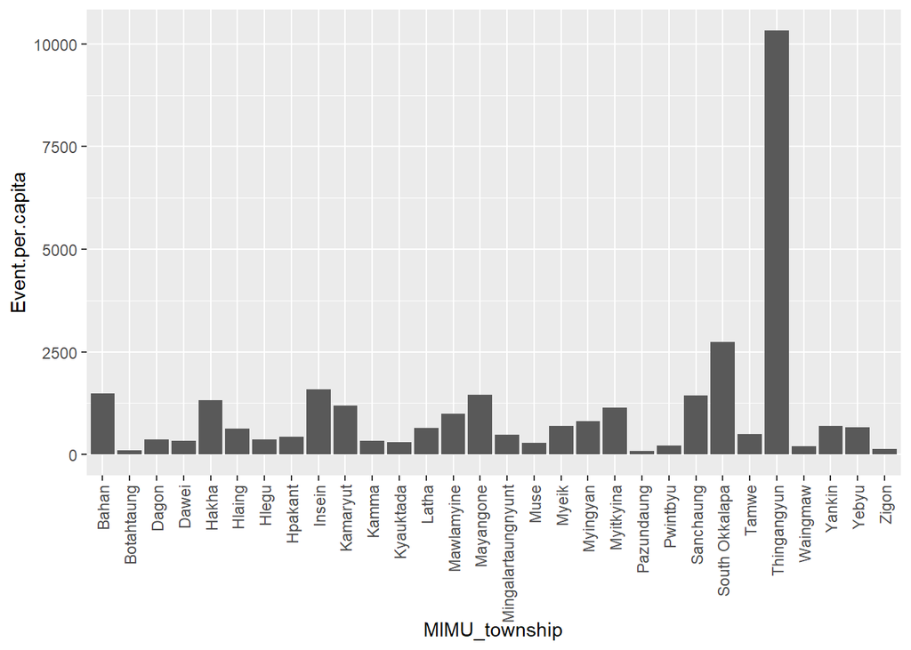

```r
#Plot detainees per capita at townships that are above the mean value
detainees_by_township %>% filter (Event.per.capita > average_det_per_capita) %>%
  ggplot(data=., aes(y=Event.per.capita, x=MIMU_township)) +
  geom_col() +
  theme(axis.text.x=element_text(angle = 90, vjust = 0.5, hjust=1))
```

The figure shows that Thingangyun did in fact had the highest number of detainees across all townships. We also see that the most number of detainment happened here. This suggest two things, either the violence was substantially more here compared to other townships or it could also mean that the forces here had lower tolerance for any display of protest and would detain protesters right away.

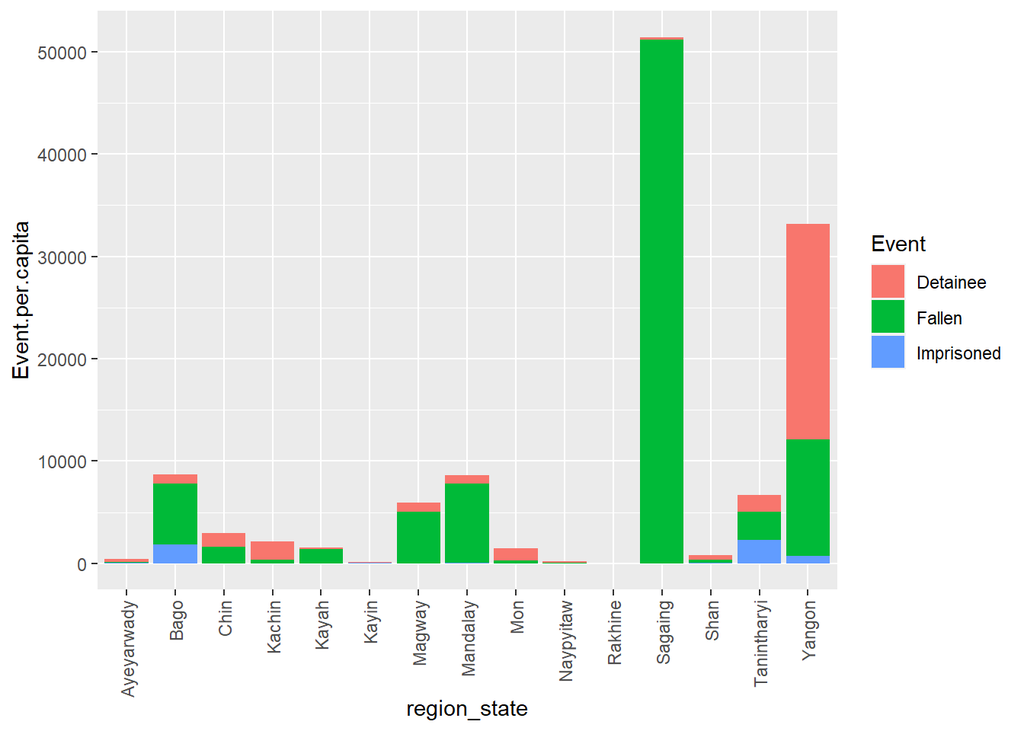

```r
#Plot total number of affected people per capita at townships
combined_datasets %>% drop_na(region_state) %>% ggplot(data=., aes(y=Event.per.capita, x=region_state, fill = Event)) +
  geom_col() +
  theme(axis.text.x=element_text(angle = 90, vjust = 0.5, hjust=1))
```

From the plot we see that the region that has been the most affected by the coup is Sagaing, followed by Yangon. Thingangyun is located in Yangon.

It is good to know which township has the highest detainmenet but we also try to see how are genders distributed across as well

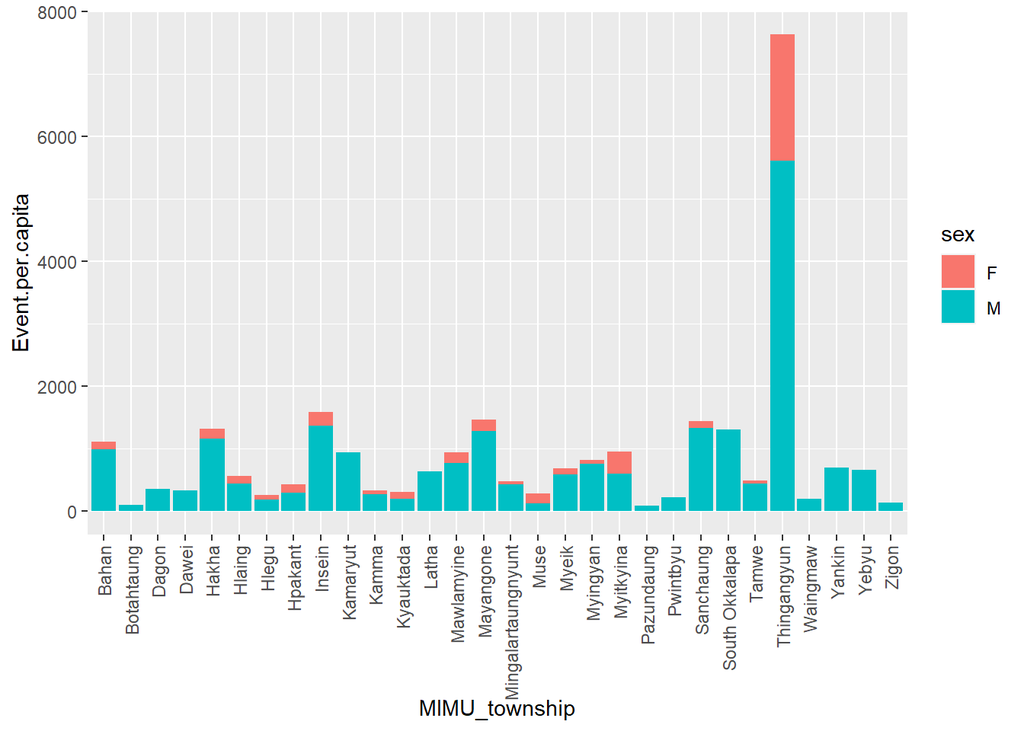

```r
#
detainees_by_township %>% drop_na() %>% group_by(MIMU_township, sex) %>% filter (Event.per.capita > average_det_per_capita) %>%
  ggplot(data=., aes(y=Event.per.capita, x=MIMU_township, fill = sex)) +
  geom_col() +
  theme(axis.text.x=element_text(angle = 90, vjust = 0.5, hjust=1))
```

How does the median age of those detained vary across townships and gender

```r
#Summarization of age and sex of detainees according to township
detainees_summary_age_sex = detainees_by_township %>% group_by(MIMU_township, sex) %>% summarise(Median_age= median(`age`))
detainees_summary_age_sex = detainees_summary_age_sex %>% arrange(desc(Median_age))
detainees_summary_age_sex
```

```
## # A tibble: 131 x 3
## # Groups:   MIMU_township [90]
##    MIMU_township sex   Median_age
##    <chr>         <chr>      <dbl>
##  1 Tedim         M           70
##  2 Pakokku       M           65
##  3 Meiktila      M           60
##  4 Kyauktada     M           54.5
##  5 Hinthada      M           50
##  6 Tamu          M           50
##  7 Pyay          F           49.5
##  8 Meiktila      F           49
##  9 Mudon         M           47
## 10 Wetlet        M           46
## # ... with 121 more rows
```

```r
min =   min(detainees_summary_age_sex$Median_age)
min
```

```
## [1] 11
```

From our results we see that minimum median age is 11 and it belongs to Pathein. The highest median age of detainee is of 70 and it belongs to Tedim

How does the relationship show for regions?

```r
#Summarization of age and sex of detainees according to region
det_summary_age_sex_region = detainees_by_township %>% group_by(`State_Region`, sex) %>% summarise(Median_age = median(`age`))
det_summary_age_sex_region = det_summary_age_sex_region %>% arrange(desc(Median_age))
det_summary_age_sex_region
```

```
## # A tibble: 33 x 3
## # Groups:   State_Region [16]
##    State_Region sex   Median_age
##    <chr>        <chr>      <dbl>
##  1 Bago         F           49.5
##  2 Mandalay     F           38.5
##  3 Kayin        M           36
##  4 Sagaing      M           32.5
##  5 <NA>         F           32
##  6 Nay Pyi Taw  M           31
##  7 Kachin       F           30.5
##  8 Yangon       F           30.5
##  9 Ayeyarwady   M           30
## 10 Ayeyarwady   F           29
## # ... with 23 more rows
```

We also want to see how the male and female were detained in each state as a percentage of all males and all females that were detain. First we just find the values for male and female by township

```r
#Create a table that contains number of detainees in each township, according to sex
detainees_township_by_sex = with(detainees_by_township, table(MIMU_township, sex))
detainees_township_by_sex
```

```
##                     sex
## MIMU_township           F    M
##   Aunglan               0    1
##   Ayadaw                2    2
##   Bago                  0   17
##   Bahan                 1    9
##   Botahtaung            0    2
##   Dagon                 0    3
##   Dala                  0    1
##   Danubyu               0    1
##   Dawbon                0    1
##   Dawei                 0    7
##   Dedaye                0    1
##   Hakha                 1    7
##   Hinthada              0    1
##   Hlaing                2    7
##   Hlegu                 2    8
##   Hpakant               4    8
##   Hsipaw                0    4
##   Ingapu                1    2
##   Insein                3   19
##   Kamaryut              0    8
##   Kamma                 1    4
##   Kangyidaunt           0    4
##   Kani                  0    1
##   Kawa                  0    1
##   Kyangin               0    3
##   Kyauktada             1    2
##   Kyauktaga             0    1
##   Kyauktan              0    1
##   Lashio                1    1
##   Latha                 0    4
##   Loikaw                3    1
##   Mawlamyine            3   14
##   Mawlamyinegyun        0    1
##   Mayangone             2   15
##   Meiktila              1    3
##   Minbu                 0    5
##   Mindat                0    1
##   Mingaladon            2    5
```

[output cut: 37 more lines]

```
##   Thaketa               0    3
##   Thanbyuzayat          0    1
##   Thandwe               3    0
##   Thanlyin              1    5
##   Thayet                0    1
##   Thayetchaung          0    1
##   Thingangyun           9   30
##   Twantay               0    1
##   Waingmaw              0    5
##   Wetlet                0    5
##   Yamethin              0    1
##   Yankin                0    7
##   Yebyu                 0    9
##   Yesagyo               0    1
##   Zigon                 0    3
```

We see the highest numbers by Township are shown in Other category (disregarding that Thingangyun has the highest detained).

```r
#Create a table that contains number of detainees in each region, according to sex
region_detainee_sex = with(detainees_by_region, table(State_Region, sex))
region_detainee_sex
```

```
##              sex
## State_Region    F   M
##   Ayeyarwady    4  19
##   Bago          2  28
##   Chin          1   9
##   Kachin       10  26
##   Kayah         3   1
##   Kayin         0   1
##   Magway        2  25
##   Mandalay      2  20
##   Mon           3  23
##   Nay Pyi Taw   0   5
##   Rakhine       3   0
##   Sagaing       3  16
##   Shan          8  13
##   Tanintharyi   2  29
##   Yangon       30 195
```

According to the table, the region that had the highest number of woman affected by the coup was Kachin and Yangon. However, it is relevant to explore proportions. We will explore the gender ratio of affected people by the coup, at the regional and township level.

```r
township_detainee_sex_prop = with(detainees_by_township, prop.table(table(MIMU_township, sex), margin = 2) %>% round(3))
township_detainee_sex_prop
```

```
##                     sex
## MIMU_township            F     M
##   Aunglan            0.000 0.001
##   Ayadaw             0.008 0.001
##   Bago               0.000 0.011
##   Bahan              0.004 0.006
##   Botahtaung         0.000 0.001
##   Dagon              0.000 0.002
##   Dala               0.000 0.001
##   Danubyu            0.000 0.001
##   Dawbon             0.000 0.001
##   Dawei              0.000 0.004
##   Dedaye             0.000 0.001
##   Hakha              0.004 0.004
##   Hinthada           0.000 0.001
##   Hlaing             0.008 0.004
##   Hlegu              0.008 0.005
##   Hpakant            0.015 0.005
##   Hsipaw             0.000 0.002
##   Ingapu             0.004 0.001
##   Insein             0.011 0.012
##   Kamaryut           0.000 0.005
##   Kamma              0.004 0.002
##   Kangyidaunt        0.000 0.002
##   Kani               0.000 0.001
##   Kawa               0.000 0.001
##   Kyangin            0.000 0.002
##   Kyauktada          0.004 0.001
##   Kyauktaga          0.000 0.001
##   Kyauktan           0.000 0.001
##   Lashio             0.004 0.001
##   Latha              0.000 0.002
##   Loikaw             0.011 0.001
##   Mawlamyine         0.011 0.009
##   Mawlamyinegyun     0.000 0.001
##   Mayangone          0.008 0.009
##   Meiktila           0.004 0.002
##   Minbu              0.000 0.003
##   Mindat             0.000 0.001
##   Mingaladon         0.008 0.003
```

[output cut: 37 more lines]

```
##   Thaketa            0.000 0.002
##   Thanbyuzayat       0.000 0.001
##   Thandwe            0.011 0.000
##   Thanlyin           0.004 0.003
##   Thayet             0.000 0.001
##   Thayetchaung       0.000 0.001
##   Thingangyun        0.034 0.019
##   Twantay            0.000 0.001
##   Waingmaw           0.000 0.003
##   Wetlet             0.000 0.003
##   Yamethin           0.000 0.001
##   Yankin             0.000 0.004
##   Yebyu              0.000 0.006
##   Yesagyo            0.000 0.001
##   Zigon              0.000 0.002
```

From the results above we see that Thingangyun has the highest number of detained by sex as a proportion of total male and females who were detained.

We repeat the similar exercise for state and region

```r
region_detainee_sex_prop = with(detainees_by_region, prop.table(table(State_Region, sex), margin = 2) %>% round(3))
region_detainee_sex_prop
```

```
##              sex
## State_Region      F     M
##   Ayeyarwady  0.055 0.046
##   Bago        0.027 0.068
##   Chin        0.014 0.022
##   Kachin      0.137 0.063
##   Kayah       0.041 0.002
##   Kayin       0.000 0.002
##   Magway      0.027 0.061
##   Mandalay    0.027 0.049
##   Mon         0.041 0.056
##   Nay Pyi Taw 0.000 0.012
##   Rakhine     0.041 0.000
##   Sagaing     0.041 0.039
##   Shan        0.110 0.032
##   Tanintharyi 0.027 0.071
##   Yangon      0.411 0.476
```

Here we see that State of Yangon has the highest proportions of arrest for both male and female as the as proportion of all males and females that were arrested. This makes sense since Thingangyun township (which has the highest detainees) is present in Yangon

**Q How detainment relates to imprisonment and death (via the imprisoned and fallen data sets)**

```r
events_by_region = combined_datasets %>% group_by(State_Region, Event) %>% summarize(count=n()) %>% pivot_wider(names_from=Event, values_from=count)
events_by_region
```

```
## # A tibble: 16 x 4
## # Groups:   State_Region [16]
##    State_Region Detainee Fallen Imprisoned
##    <chr>           <int>  <int>      <int>
##  1 Ayeyarwady         23     11          6
##  2 Bago               30     83         17
##  3 Chin               10     17         NA
##  4 Kachin             36     19         NA
##  5 Kayah               4     17         NA
##  6 Kayin               1     NA         NA
##  7 Magway             28     82          2
##  8 Mandalay           22    120          5
##  9 Mon                26     18          1
## 10 Nay Pyi Taw         5      5         NA
## 11 Rakhine             3     NA         NA
## 12 Sagaing            20    244          1
## 13 Shan               21     61          5
## 14 Tanintharyi        31     42         33
## 15 Yangon            240    171         24
## 16 <NA>             1427    267        209
```

```r
events_by_township = combined_datasets %>% group_by(MIMU_township, Event) %>% summarize(count=n()) %>% pivot_wider(names_from=Event, values_from=count)
events_by_township
```

```
## # A tibble: 177 x 4
## # Groups:   MIMU_township [177]
##    MIMU_township  Fallen Imprisoned Detainee
##    <chr>           <int>      <int>    <int>
##  1 Amarapura           6          1       NA
##  2 Aunglan             2         NA        1
##  3 Aungmyaythazan      3         NA       NA
##  4 Ayadaw              4         NA        4
##  5 Bago               51          2       17
##  6 Bahan               2         NA       12
##  7 Botahtaung          2         NA        2
##  8 Budalin             3         NA       NA
##  9 Chanmyathazi       13         NA       NA
## 10 Chauk               2         NA       NA
## # ... with 167 more rows
```

#When did detainment occured?

```r
#Lets get a table that has the proportion of detainees at each month, since the start of the coup (February 2021)
township_detainee_Event_prop = with(detainees_by_township, prop.table(table(date_of_event, Event), margin = 2) %>% round(3))
township_detainee_Event_prop
```

```
##              Event
## date_of_event Detainee
##     April        0.104
##     August       0.057
##     February     0.028
##     July         0.094
##     June         0.085
##     March        0.205
##     May          0.124
##     November     0.080
##     October      0.075
##     September    0.148
```

The detainment has a maximum number of people detained in March. Since the coup began in February, the military was taking less actions against the protesters. We Know that protests increased after two protesters were killed in March. This results accurately capture that most people were arrested in March.

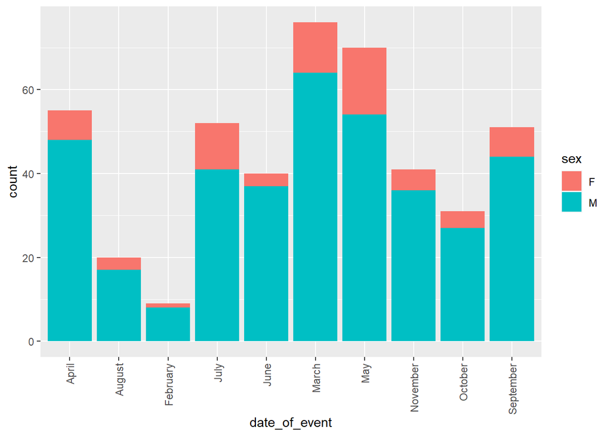

```r
# Number of men and women detained over each month
detainees_by_region %>% drop_na() %>% group_by(date_of_event, sex) %>%
  summarise(count=n()) %>%
  ggplot(data=., aes(y=count, x=date_of_event, fill = sex)) +
  geom_col() +
  theme(axis.text.x=element_text(angle = 90, vjust = 0.5, hjust=1))
```

The figure above shows the distribution of detainees by month and by gender. Most people detained in a single month happened in March with more males than females being imprisoned.

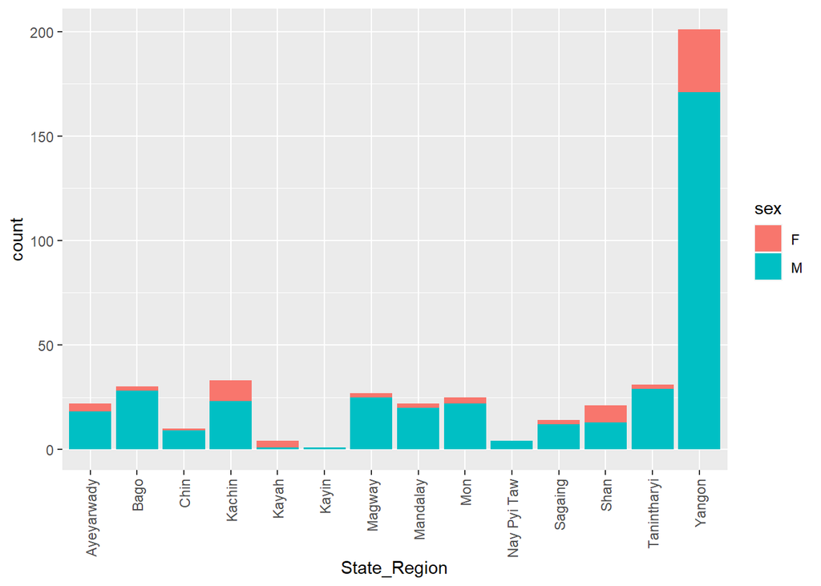

```r
# Number of men and women detained in each Region
detainees_by_region %>% drop_na() %>% group_by(State_Region, sex) %>%
  summarise(count=n()) %>%
  ggplot(data=., aes(y=count, x=State_Region, fill = sex)) +
  geom_col() +
  theme(axis.text.x=element_text(angle = 90, vjust = 0.5, hjust=1))
```

The figure above shows the distribution of detainees by region and by gender.

17. How detainment relates to imprisonment and death

**Statistical Testing**

**Test

H0:There is no difference between the age averages of the two groups

versus

Ha:There is a difference between the age averages of the two groups.

```r
st_detained_imprisoned <-subset(combined_datasets, Event!="Fallen")
```

We first plot the distribution of Detainees and Imprisoned across different age groups, we find that the observations are normally distributed, however they are righ skewed.

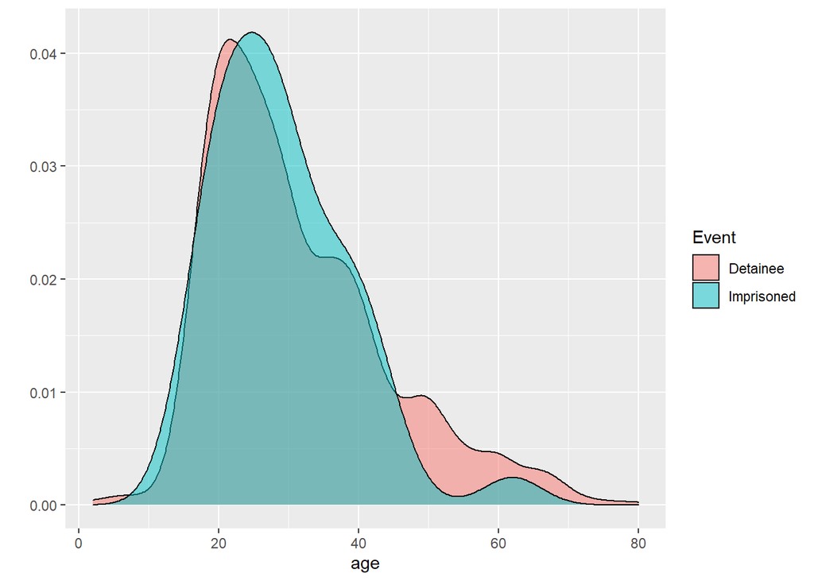

```r
qplot(data = st_detained_imprisoned, x = age,
fill = Event, geom = "density", alpha = I(0.5))
```

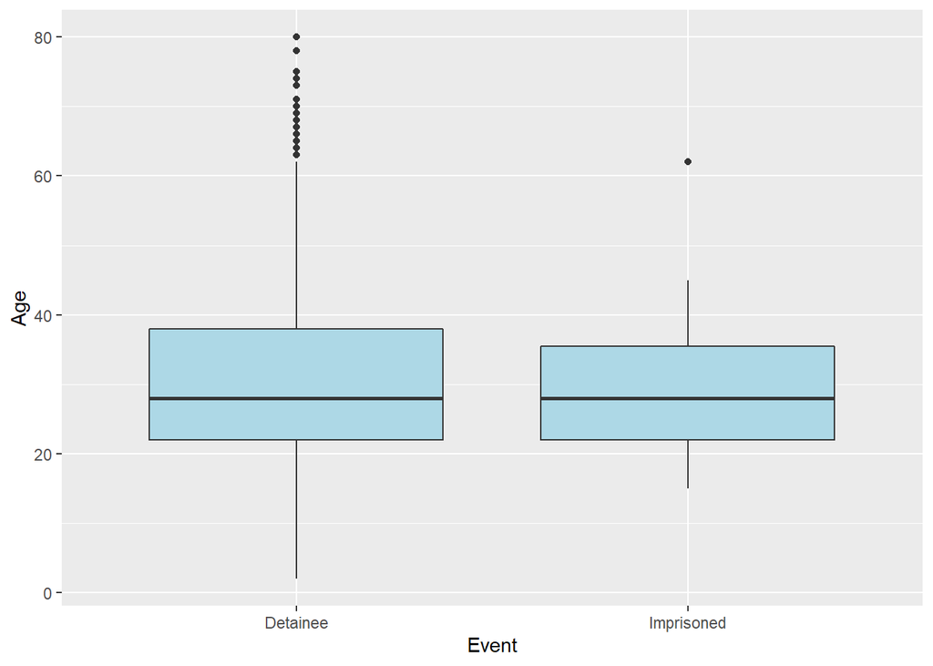

```r
qplot(x = Event, y = age,
      geom = "boxplot", data = st_detained_imprisoned,
      xlab = "Event",
      ylab = "Age",
      fill = I("lightblue"))
```

The distribution shows that both detainees and imprisoned are distributed similarly over age. We see that both distributions have a right skew. From the boxplot, we see that there is not a substantial difference in the mean of two categories. However we will continue to use our testing methodology to get the answer

We also see that the mean age of the detained and imprisoned is about the same. Detainees is slightly more varied than Imprisoners over the age group. This shows that there are no people in certain age group who have a higher likely hood to get sentenced an imprisonment

We first perform the T-test

```r
mpg.t.test <- t.test(age ~ Event, data = st_detained_imprisoned)
mpg.t.test
```

```
##
##  Welch Two Sample t-test
##
## data:  age by Event
## t = 1.4408, df = 40.732, p-value = 0.1573
## alternative hypothesis: true difference in means between group Detainee and group Imprisoned is not equal to 0
## 95 percent confidence interval:
##  -0.908723  5.429926
## sample estimates:
##   mean in group Detainee mean in group Imprisoned
##                 31.31188                 29.05128
```

```r
with(st_detained_imprisoned, t.test(x = age[Event == "Detainee"], y = age[Event == "Imprisoned"]))
```

```
##
##  Welch Two Sample t-test
##
## data:  age[Event == "Detainee"] and age[Event == "Imprisoned"]
## t = 1.4408, df = 40.732, p-value = 0.1573
## alternative hypothesis: true difference in means is not equal to 0
## 95 percent confidence interval:
##  -0.908723  5.429926
## sample estimates:
## mean of x mean of y
##  31.31188  29.05128
```

The results show that there is a slight difference in mean age of detained and imprisoned.However, the p-value associated with the test is 0.1572911 so we cannot reject the null hypothesis (H0) of no difference between the (true) averages of the two groups since the p-value is greater than the usual significance level alpha = 0.05. Based on these data, we conclude that there is not enough evidence of a difference between the (true) averages of the two groups at the usual significance level of alpha = 0.05.

```r
mpg.t.test$conf.int
```

```
## [1] -0.908723  5.429926
## attr(,"conf.level")
## [1] 0.95
```

```r
mpg.wilcox.test <- wilcox.test(age ~ Event, data = st_detained_imprisoned)
```

```r
mpg.wilcox.test
```

```
##
##  Wilcoxon rank sum test with continuity correction
##
## data:  age by Event
## W = 40030, p-value = 0.4845
## alternative hypothesis: true location shift is not equal to 0
```

This is simmilar result to what we found in Welch two sample t-test.

Hence we can can conclude that there is no statistical difference in the median age of the two groups

```r
#Lets create a subset that contains only information from Detainees and Fallen
st_detained_fallen <-subset(combined_datasets, Event!="Imprisoned")
```

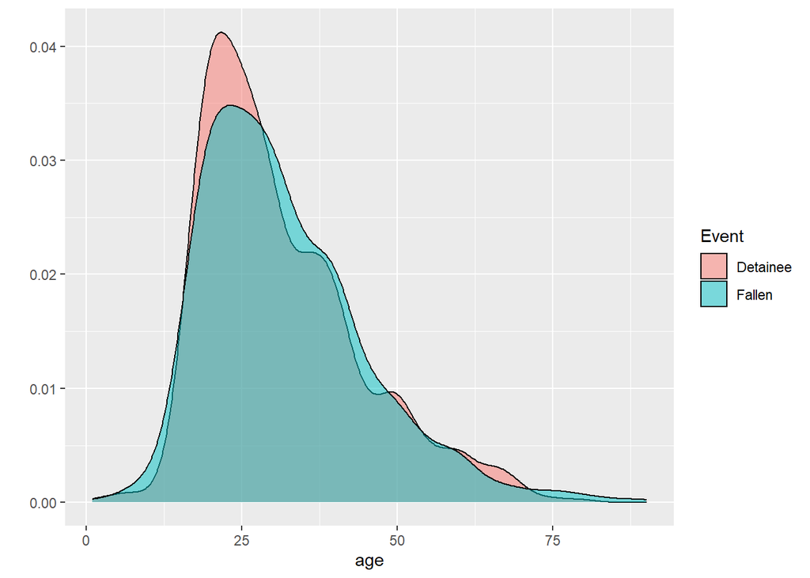

```r
#Lets check if the data is normally distributed
qplot(data = st_detained_fallen, x = age,
fill = Event, geom = "density", alpha = I(0.5))
```

As we can see in the figure, the age variable has a normal distribution for the detainee and fallen datasets. However, age appears to be skewed right.

```r
#Lets perform a t-test
age.t.test <- t.test(age ~ Event, data = st_detained_fallen)
age.t.test
```

```
##
##  Welch Two Sample t-test
##
## data:  age by Event
## t = -1.0797, df = 1674.5, p-value = 0.2804
## alternative hypothesis: true difference in means between group Detainee and group Fallen is not equal to 0
## 95 percent confidence interval:
##  -1.6051378  0.4653918
## sample estimates:
## mean in group Detainee   mean in group Fallen
##               31.31188               31.88176
```

The results show that there is a slight difference in mean age of detained and fallen. However, the p-value associated with the test is 0.2804472 so we cannot reject the null hypothesis (H0) of no difference between the (true) averages of the two groups since the p-value is greater than the usual significance level alpha = 0.05. Based on these data, we conclude that there is not enough evidence of a difference between the (true) averages of the two groups at the usual significance level of alpha = 0.05.

```r
#Lets check if the data is normally distributed
with(st_detained_fallen, t.test(x = age[Event == "Detainee"], y = age[Event == "Fallen"]))
```

```
##
##  Welch Two Sample t-test
##
## data:  age[Event == "Detainee"] and age[Event == "Fallen"]
## t = -1.0797, df = 1674.5, p-value = 0.2804
## alternative hypothesis: true difference in means is not equal to 0
## 95 percent confidence interval:
##  -1.6051378  0.4653918
## sample estimates:
## mean of x mean of y
##  31.31188  31.88176
```

```r
#Lets retrieve the confidence interval
age.t.test$conf.int
```

```
## [1] -1.6051378  0.4653918
## attr(,"conf.level")
## [1] 0.95
```

```r
#Lets perform a Wilcox test
mpg.wilcox.test <- wilcox.test(age ~ Event, data = st_detained_fallen)
mpg.wilcox.test
```

```
##
##  Wilcoxon rank sum test with continuity correction
##
## data:  age by Event
## W = 830293, p-value = 0.2066
## alternative hypothesis: true location shift is not equal to 0
```

# Is there any association between the events and gender?

We will run a chi-square analysis to see if there is any association between the Events and Gender, in other words we aim to explain if there is any uneven distribution on how the type of event affects the population based on gender.

Our null hypothesis state that there is no significant difference between gender and type of event.  
Our alternative hypothesis state that the gender is related to the type of events that affect the population.

Our significance level is 95%, alpha = 0.05

When performing the chisq test, we find that the p-value is less than 0.05. We reject the null hypothesis, in Myanmmar the coup events are related to gender.

```r
#Lets retrieve the count of men and woman affected by each event of the coup
combined_datasets %>% group_by(Event, sex) %>% summarize(count=n()) %>% pivot_wider(names_from=Event, values_from=count) %>% drop_na()
```

```
## # A tibble: 2 x 4
##   sex   Detainee Fallen Imprisoned
##   <chr>    <int>  <int>      <int>
## 1 F          264     80         53
## 2 M         1613   1055        248
```

```r
#Lets create a table that contains the count of men and woman affected by each event of the coup
event_gender = as.table(rbind(c(264, 80, 53), c(1613, 1055, 248)))
dimnames(event_gender) = list(sex = c("F", "M"), Event = c("Detainee","Fallen", "Imprisoned"))
```

```r
#Lets perform the chisq test using the table that contains the counts
chisq.test(event_gender)
```

```
##
##  Pearson's Chi-squared test
##
## data:  event_gender
## X-squared = 42.947, df = 2, p-value = 4.722e-10
```

#We will also conduct a fisher test between event and gender, considering only two events: detainee and fallen.

We will run a fisher test analysis to see if there is any association between Events and Gender, in other words we aim to explain if there is any uneven distribution on how the type of events detainment and fallen affect the population based on gender.

Our null hypothesis state that there is no significant difference between gender and these type of events.  
Our alternative hypothesis state that the gender is related to the type of events that affect the population.

Our significance level is 95%, alpha = 0.05

```r
#Lets gather only the counts for Fallen and Detainee
event_gender.det.fallen = event_gender[,c(2,1)]
```

```r
#Lets perform the chisq test using the table that contains the counts
ftest = fisher.test(event_gender.det.fallen)
```

When performing the fisher test, we find that the pvalue 1.8527866^{-9} is less than 0.05. We reject the null hypothesis, in Myanmmar the proportions of detainee and fallen are associated to gender.

**Q What drives detainment in Mayanmar from a geographic, social and economics perspective**

#Regression. What drives detainment in Myanmar from a geographic, social, and economic perspective (MIMU and conflicts data sets).

#Lets retrieve the indicators information from the sector.nest (MIMU) dataset, When choosing variables that could explain the detainment, we chose numeric variables that had observations for most of the 330 townships in Myanmmar.

```r
#Approximate number of Vulnerable population
vulnerable.pop = sector.nest %>% filter(Indicator_Name=="Approximate Vulnerable Population", Indicator_Type=="Total", str_detect(Source_Name, "Vulnerability Study")) %>% unnest(everything()) %>% rename(Vulnerable_Population = Value)

#Number of female headed houses
female_headed_households.pop = sector.nest %>% filter(Indicator_Name=="Number of Female-headed households", Indicator_Type=="Total", str_detect(Source_Name, "MMR_MOIP/DOP, The 2014 Myanmar Population and Hous")) %>% unnest(everything()) %>% rename(Female_Leaded_Houses = Value)

#Population 25 yr and over by highest level of educaiton completed
pop.highest.level.education = sector.nest %>% filter(Indicator_Name=="Population 25 yr and over by highest level of educaiton completed", Indicator_Type=="Middle school - Total", str_detect(Source_Name, "MMR_MOIP/DOP, The 2014 Myanmar Population and Housing Censu")) %>% unnest(everything()) %>% rename(Population_completed_Middle_school = Value)

#Number of households which have Internet at home
internet.access = sector.nest %>% filter(Indicator_Name=="Number of households which have Internet at home", Indicator_Type=="Total", str_detect(Source_Name, "MMR_MOIP/DOP, The 2014 Myanmar Population and Housing Census")) %>% unnest(everything()) %>% rename(Households_Internet = Value)

#Number of employees at the private sector
employee = sector.nest %>% filter(Indicator_Name=="Population (10 yr and over) by usual activity status", Indicator_Type=="Employee (private) - Total", str_detect(Source_Name, "MMR_MOIP/DOP, The 2014 Myanmar Population and Housing Census")) %>% unnest(everything()) %>% rename(Employees = Value)
```

```r
#Lets create a df that contains all the indicators for regression
df = vulnerable.pop %>% inner_join(female_headed_households.pop, by = "Township_Name") %>% inner_join(pop.highest.level.education, by = "Township_Name") %>% inner_join(internet.access, by = "Township_Name") %>% inner_join(employee, by = "Township_Name")

#lets create a subset that contains only the observations for Detainees
st_detainee_for_reg = subset(combined_datasets, Event=="Detainee") %>% rename(Township_Name = MIMU_township)
```

```r
#Lets join the subset and the df with the indicators
df_reg = df %>% inner_join(st_detainee_for_reg, by = "Township_Name")

#lets group by township
df_reg_township_observations = df_reg %>% group_by(Township_Name)
```

#Exploring detainment and conflicts

When exploring the association between the conflicts and number of detainees, we decided to consider the number of conflicts per capita in each township.

```r
#Lets merge the observations for detainment and conflicts, based on Township
#In the conflicts df, lets change the column name admin3 to Township_Name, so we can join on this column
conflicts = conflicts %>% rename(Township_Name = admin3)
#We decide to gather information about the number of fatalities and number of conflicts per township
conflicts = conflicts %>% nest(nested.data = -c(Township_Name)) %>% mutate(Number_of_conflicts = map_dbl(nested.data, nrow)) %>% mutate(Number_of_fatalities = map_dbl(nested.data, ~ sum(.x$fatalities)))

#Lets join the conflicts df with the township.sizes df, so we can calculate the number of conflicts and fatalities per capita
df_conflicts = conflicts %>% inner_join(township.sizes, by = "Township_Name")
```

```r
#Lets calculate in a per capita basis
df_conflicts = df_conflicts %>% mutate(fatalities.per.1000 = Number_of_fatalities/Value) %>% mutate(conflicts.per.1000 = Number_of_conflicts/Value)
```

```r
#Lets calculate in a per capita basis
df_conflicts = df_conflicts %>% mutate(fatalities.per.1000 = Number_of_fatalities/Value) %>% mutate(conflicts.per.1000 = Number_of_conflicts/Value)
```

```r
#Lets join the conflicts df with the detainees df, that contains the detainees per capita
df_conflicts_det = df_conflicts %>% inner_join(st_detainee_for_reg %>% nest(nested.data = -c(Township_Name, Event.per.capita)), by = "Township_Name")
```

```r
#Lets join the conflicts df with the detainees df, that contains the detainees per capita and also, lets join with the indicators retrieved from sector.nest
df_conflicts_det = df_conflicts %>% inner_join(st_detainee_for_reg %>% nest(nested.data = -c(Township_Name, Event.per.capita)), by = "Township_Name") %>% inner_join(df, by = "Township_Name")
```

```r
#Lets join the conflicts df with the detainees df, that contains the detainees per capita and also, lets join with the indicators retrieved from sector.nest
 df_conflicts_det = df_conflicts %>% inner_join(st_detainee_for_reg %>% nest(nested.data = -c(Township_Name, Event.per.capita)), by = "Township_Name") %>% inner_join(df, by = "Township_Name")
```

```r
#Lets join the conflicts df with the detainees df, that contains the detainees per capita and also, lets join with the indicators retrieved from sector.nest
df_conflicts_det = df_conflicts %>% inner_join(st_detainee_for_reg %>% nest(nested.data = -c(Township_Name, Event.per.capita)), by = "Township_Name") %>% inner_join(df, by = "Township_Name") %>%
  mutate(Vulnerable_Population.per.1000 = Vulnerable_Population/Value) %>%
  mutate(Female_Leaded_Houses.per.1000 = Female_Leaded_Houses/Value) %>%
  mutate(Population_completed_Middle_school.per.1000 = Population_completed_Middle_school/Value) %>%
  mutate(Households_Internet.per.1000 = Households_Internet/Value)  %>%
  mutate(Employees.per.1000 = Employees/Value)
```

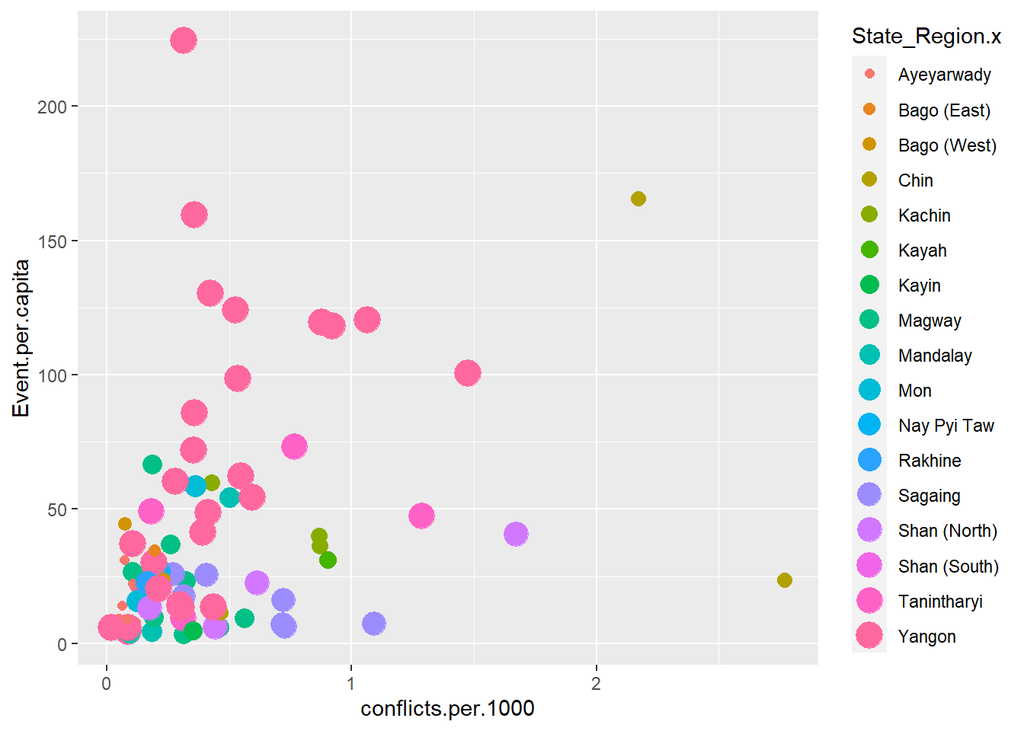

```r
ggplot(data = df_conflicts_det, aes(x = conflicts.per.1000, y = Event.per.capita, color=State_Region.x, size=State_Region.x)) + geom_point()
```

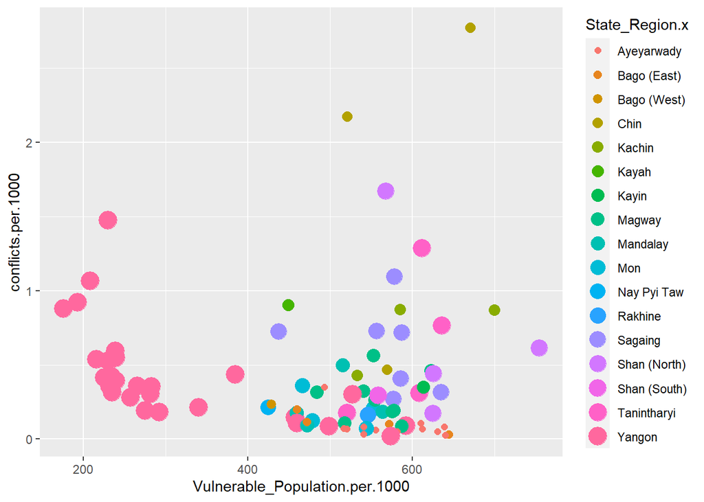

```r
ggplot(data = df_conflicts_det, aes(x = Vulnerable_Population.per.1000, y = conflicts.per.1000, color=State_Region.x, size=State_Region.x)) + geom_point()
```

Based on our finding that the variable vulnerable population seems to have an association with the number of detainees, we decided to explore the association between conflicts per capita and vulnerable population per capita. The scatter plot contains the observations of conflicts and vulnerable population per capita at township. Again, Yangon is the region that shows a strong association, however it seems that there is a negative association between the two variables. This could mean that townships in Yangon that had more vulnerable population were not deeply affected by the conflicts in 2021.

**Linear Regression**

We will now be conducting linear regressions to observe how our predictor variables share a relationship with the dependent variable.

For our first plot we will be trying to plot how the attributes of number of employed people by township (Employees), total number of households with internet access (Households_Internet) by township, the number of people categorised as vulnerable population per township (Vulnerable_Population) and the population per township. We will first check if these predictors are statistically relevant by checking their P values. and then check if the predictors have any collinearity between each other to ensure our results are not biased.

```r
#Creating a regresssion object mayan.lm which will be doing the regression between Event.percapita and the rest of the predictors mentioned in the prompt above

mayan.lm <- lm(Event.per.capita ~ Vulnerable_Population.per.1000 + Female_Leaded_Houses.per.1000 + Population_completed_Middle_school.per.1000 + Households_Internet.per.1000 + Employees.per.1000 ,
   data = df_conflicts_det)
```

```r
#Let us now find out the summary from our regression.
kable(summary(mayan.lm)$coef, digits = c(3, 3, 3, 4), format = "markdown")
```

|  | Estimate | Std. Error | t value | Pr(>\|t\|) |
| --- | --- | --- | --- | --- |
| (Intercept) | 140.816 | 58.133 | 2.422 | 0.0176 |
| Vulnerable_Population.per.1000 | -0.154 | 0.066 | -2.319 | 0.0229 |
| Female_Leaded_Houses.per.1000 | -0.210 | 0.300 | -0.701 | 0.4851 |
| Population_completed_Middle_school.per.1000 | -0.091 | 0.181 | -0.505 | 0.6147 |
| Households_Internet.per.1000 | 0.439 | 0.272 | 1.615 | 0.1100 |
| Employees.per.1000 | -0.118 | 0.084 | -1.413 | 0.1614 |

```r
summary(mayan.lm)
```

```
##
## Call:
## lm(formula = Event.per.capita ~ Vulnerable_Population.per.1000 +
##     Female_Leaded_Houses.per.1000 + Population_completed_Middle_school.per.1000 +
##     Households_Internet.per.1000 + Employees.per.1000, data = df_conflicts_det)
##
## Residuals:
##     Min      1Q  Median      3Q     Max
## -55.244 -17.316  -8.322   9.574 141.077
##
## Coefficients:
##                                              Estimate Std. Error t value
## (Intercept)                                 140.81599   58.13310   2.422
## Vulnerable_Population.per.1000               -0.15353    0.06622  -2.319
## Female_Leaded_Houses.per.1000                -0.21014    0.29965  -0.701
## Population_completed_Middle_school.per.1000  -0.09135    0.18078  -0.505
## Households_Internet.per.1000                  0.43922    0.27188   1.615
## Employees.per.1000                           -0.11822    0.08367  -1.413
##                                             Pr(>|t|)
## (Intercept)                                   0.0176 *
## Vulnerable_Population.per.1000                0.0229 *
## Female_Leaded_Houses.per.1000                 0.4851
## Population_completed_Middle_school.per.1000   0.6147
## Households_Internet.per.1000                  0.1100
## Employees.per.1000                            0.1614
## ---
## Signif. codes:  0 '***' 0.001 '**' 0.01 '*' 0.05 '.' 0.1 ' ' 1
##
## Residual standard error: 32.99 on 82 degrees of freedom
## Multiple R-squared:  0.4312, Adjusted R-squared:  0.3966
## F-statistic: 12.43 on 5 and 82 DF,  p-value: 5.493e-09
```

*Methodology for regression* Let us now see if there are any predictors that have high correlations between themselves. we can thus see if any single variable from a correlated pair can be dropped to see if our regression R-squared improves, or p-value of other variables improves.

we will be Running the pairs command on the following set of variables: “Vulnerable_Population” , “Female_Leaded_Houses” , “Population_completed_Middle_school” , “Households_Internet” , “Employees”.

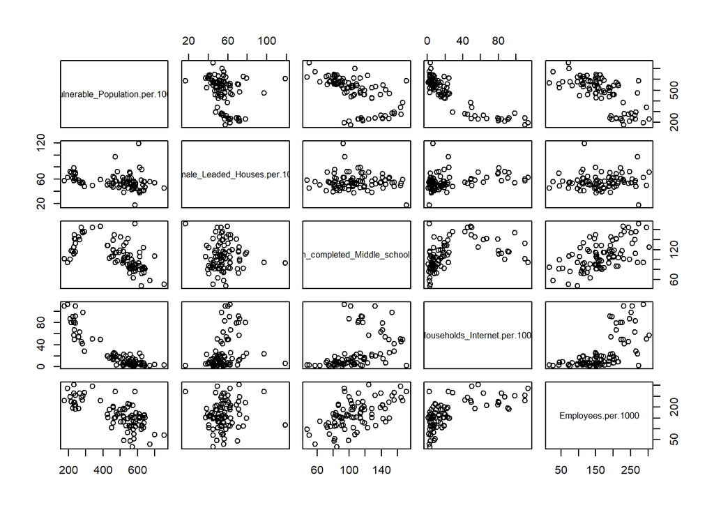

```r
pairs(df_conflicts_det[,c("Vulnerable_Population.per.1000",  "Female_Leaded_Houses.per.1000","Population_completed_Middle_school.per.1000", "Households_Internet.per.1000","Employees.per.1000")])
```

Let us now Rerun our regression but without the statistically insignificant variables. Let us see if our regression results improve. Below is shown a scatter plot that gives a hint that there is an association between the number of vulnerable population at each township and the number of detainees in the township.

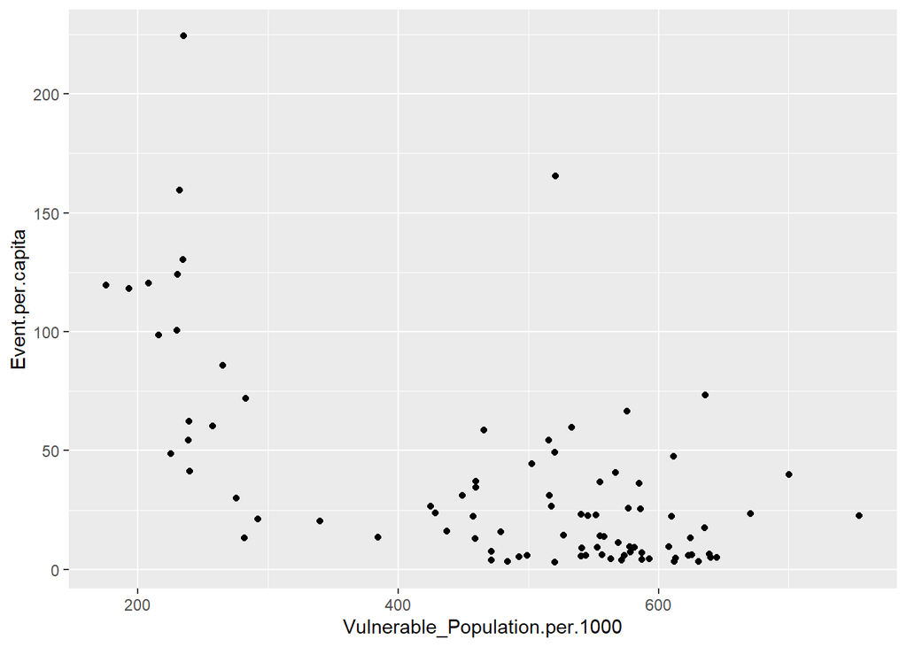

```r
#lets display a scatter plot
ggplot(data = df_conflicts_det, aes(x = Vulnerable_Population.per.1000, y = Event.per.capita)) + geom_point()
```

```r
#Creating a regresssion object mayan.lm2 which will be doing the regression between Event.percapita and Vulnerable_Population.per.1000
mayan.lm2 <- lm(Event.per.capita ~ Vulnerable_Population.per.1000 ,
   data = df_conflicts_det)
```

```r
summary(mayan.lm)
```

```
##
## Call:
## lm(formula = Event.per.capita ~ Vulnerable_Population.per.1000 +
##     Female_Leaded_Houses.per.1000 + Population_completed_Middle_school.per.1000 +
##     Households_Internet.per.1000 + Employees.per.1000, data = df_conflicts_det)
##
## Residuals:
##     Min      1Q  Median      3Q     Max
## -55.244 -17.316  -8.322   9.574 141.077
##
## Coefficients:
##                                              Estimate Std. Error t value
## (Intercept)                                 140.81599   58.13310   2.422
## Vulnerable_Population.per.1000               -0.15353    0.06622  -2.319
## Female_Leaded_Houses.per.1000                -0.21014    0.29965  -0.701
## Population_completed_Middle_school.per.1000  -0.09135    0.18078  -0.505
## Households_Internet.per.1000                  0.43922    0.27188   1.615
## Employees.per.1000                           -0.11822    0.08367  -1.413
##                                             Pr(>|t|)
## (Intercept)                                   0.0176 *
## Vulnerable_Population.per.1000                0.0229 *
## Female_Leaded_Houses.per.1000                 0.4851
## Population_completed_Middle_school.per.1000   0.6147
## Households_Internet.per.1000                  0.1100
## Employees.per.1000                            0.1614
## ---
## Signif. codes:  0 '***' 0.001 '**' 0.01 '*' 0.05 '.' 0.1 ' ' 1
##
## Residual standard error: 32.99 on 82 degrees of freedom
## Multiple R-squared:  0.4312, Adjusted R-squared:  0.3966
## F-statistic: 12.43 on 5 and 82 DF,  p-value: 5.493e-09
```

```r
r1 <- summary(mayan.lm)$r.squared
```

```r
summary(mayan.lm2)
```

```
##
## Call:
## lm(formula = Event.per.capita ~ Vulnerable_Population.per.1000,
##     data = df_conflicts_det)
##
## Residuals:
##     Min      1Q  Median      3Q     Max
## -60.098 -18.763  -6.163  13.288 142.433
##
## Coefficients:
##                                 Estimate Std. Error t value Pr(>|t|)
## (Intercept)                    124.95490   12.43190  10.051 3.59e-16 ***
## Vulnerable_Population.per.1000  -0.18317    0.02467  -7.424 7.63e-11 ***
## ---
## Signif. codes:  0 '***' 0.001 '**' 0.01 '*' 0.05 '.' 0.1 ' ' 1
##
## Residual standard error: 33.34 on 86 degrees of freedom
## Multiple R-squared:  0.3906, Adjusted R-squared:  0.3835
## F-statistic: 55.11 on 1 and 86 DF,  p-value: 7.629e-11
```

```r
r2 <- summary(mayan.lm2)$r.squared
```

We can only conclude from this that there are most certainly other variables that we haven’t included, that could better explain the regression.

We havent tried other regression models. we need to check if a ridge, lasso or polynomial regression could better explain the regression.